# 不真面目回答の効果検証

Your Name

2025-12-02

# 不真面目回答に対するLLMを活用したナッジ介入の効果の検討：クラウドソーシングを用いて

概要：本研究は，クラウドソーシングによるアンケート調査において，努力最小化（satisfice）により生じる不真面目回答の抑制を目的とし，ナッジ介入の効果を検証するものである．従来から用いられてきた事前申告や利得強調，損失回避型の手法に加え，大規模言語モデル（LLM）により生成されたナッジメッセージが回答品質の向上に寄与するかを，アンケート回答者をランダムに振り分けて比較する平均処置効果（ATE）によって検証した．その結果，利得強調や損失回避による介入で抑制させる効果がみられたものの，すべての介入群で統計的に有意な抑制効果は見られなかった．このことから，不真面目回答に対する効果は存在したとしても小さな効果量であり，本研究のサンプル規模（各群約180）では統計的に有意な差として検出するには不十分であったことが示唆された．

## ライブラリの読み込み

```r
pacman::p_load(
  tidyverse,
  ggplotgui,#ggplot_shiny(exdataset)
  GGally,
  broom,
  kableExtra,
  ### table1を表にしてまとめやすく
  table1,
  sjPlot
)
```

# 1. データ前処理・加工

5つのデータセットを読み込み、基本データセットから必要なカラムを抽出して一つの新しいデータフレームを作成

ダミー回帰分析用にone-hot encodingを実施する

## 1-2. データの読み込み

```r
# 各データセットの読み込み
basic <- read_csv("../data/basic_2025-10-24.csv")
gain_emphasis <- read_csv("../data/gain_emphasis_2025-10-24.csv")
loss_aversion <- read_csv("../data/loss_aversion_2025-10-24.csv")
pre_commitment <- read_csv("../data/pre_commitment_2025-10-24.csv")
using_llm <- read_csv("../data/using_llm_2025-10-24.csv")
```

## 1-3. basicデータの加工

必要な列のみ抽出し、category列を追加（以降using_llmまで同じ）

```r
# basicデータから必要なカラムを抽出してbasic_dfを作成
basic_df <- basic %>%
  select(
    participant.id_in_session,
    participant._index_in_pages,
    participant.time_started_utc,
    starts_with("player.q_"),  # player.q_gender, player.q_age, etc.
    starts_with("player.big5_"), # BigFive関連
    starts_with("player.inboron"), # 陰謀論関連
    starts_with("player.crt_")   # CRT関連
  ) %>%
  mutate(category = "basic")  # categoryカラムを追加

# basic_dfの先頭6行を表示
head(basic_df)
```

```
## # A tibble: 6 × 42
##   participant.id_in_session participant._index_in_pages participant.time_start…¹
##                       <dbl>                       <dbl> <time>
## 1                         1                           8 43'00"
## 2                         2                           8 44'00"
## 3                         3                           8 44'00"
## 4                         4                           8 45'00"
## 5                         5                           8 45'00"
## 6                         6                           8 45'00"
## # ℹ abbreviated name: ¹participant.time_started_utc
## # ℹ 39 more variables: player.q_gender <dbl>, player.q_age <dbl>,
## #   player.q_area <dbl>, player.q_education <dbl>, player.q_device <dbl>,
## #   player.big5_1 <dbl>, player.big5_2 <dbl>, player.big5_3 <dbl>,
## #   player.big5_4 <dbl>, player.big5_5 <dbl>, player.big5_6 <dbl>,
## #   player.big5_7 <dbl>, player.big5_IMC <dbl>, player.big5_8 <dbl>,
## #   player.big5_9 <dbl>, player.big5_10 <dbl>, player.inboron1 <dbl>, …
```

## 1-4. gain_emphasisデータの加工

```r
# gain_emphasisデータから必要なカラムを抽出してgain_emphasis_dfを作成
gain_emphasis_df <- gain_emphasis %>%
  select(
    participant.id_in_session,
    participant._index_in_pages,
    participant.time_started_utc,
    starts_with("player.q_"),  # player.q_gender, player.q_age, etc.
    starts_with("player.big5_"), # BigFive関連
    starts_with("player.inboron"), # 陰謀論関連
    starts_with("player.crt_")   # CRT関連
  ) %>%
  mutate(category = "gain_emphasis")  # categoryカラムを追加

# gain_emphasis_dfの先頭6行を表示
head(gain_emphasis_df)
```

```
## # A tibble: 6 × 42
##   participant.id_in_session participant._index_in_pages participant.time_start…¹
##                       <dbl>                       <dbl> <time>
## 1                         1                           9 43'00"
## 2                         2                           9 43'00"
## 3                         3                           9 44'00"
## 4                         4                           9 44'00"
## 5                         5                           9 45'00"
## 6                         6                           9 45'00"
## # ℹ abbreviated name: ¹participant.time_started_utc
## # ℹ 39 more variables: player.q_gender <dbl>, player.q_age <dbl>,
## #   player.q_area <dbl>, player.q_education <dbl>, player.q_device <dbl>,
## #   player.big5_1 <dbl>, player.big5_2 <dbl>, player.big5_3 <dbl>,
## #   player.big5_4 <dbl>, player.big5_5 <dbl>, player.big5_6 <dbl>,
## #   player.big5_7 <dbl>, player.big5_IMC <dbl>, player.big5_8 <dbl>,
## #   player.big5_9 <dbl>, player.big5_10 <dbl>, player.inboron1 <dbl>, …
```

## 1-5. loss_aversionデータの加工

```r
# loss_aversionデータから必要なカラムを抽出してloss_aversion_dfを作成
loss_aversion_df <- loss_aversion %>%
  select(
    participant.id_in_session,
    participant._index_in_pages,
    participant.time_started_utc,
    starts_with("player.q_"),  # player.q_gender, player.q_age, etc.
    starts_with("player.big5_"), # BigFive関連
    starts_with("player.inboron"), # 陰謀論関連
    starts_with("player.crt_")   # CRT関連
  ) %>%
  mutate(category = "loss_aversion")  # categoryカラムを追加

# loss_aversion_dfの先頭6行を表示
head(loss_aversion_df)
```

```
## # A tibble: 6 × 42
##   participant.id_in_session participant._index_in_pages participant.time_start…¹
##                       <dbl>                       <dbl> <time>
## 1                         1                           9 44'00"
## 2                         2                           9 45'00"
## 3                         3                           9 46'00"
## 4                         4                           9 46'00"
## 5                         5                           9 46'00"
## 6                         6                           9 46'00"
## # ℹ abbreviated name: ¹participant.time_started_utc
## # ℹ 39 more variables: player.q_gender <dbl>, player.q_age <dbl>,
## #   player.q_area <dbl>, player.q_education <dbl>, player.q_device <dbl>,
## #   player.big5_1 <dbl>, player.big5_2 <dbl>, player.big5_3 <dbl>,
## #   player.big5_4 <dbl>, player.big5_5 <dbl>, player.big5_6 <dbl>,
## #   player.big5_7 <dbl>, player.big5_IMC <dbl>, player.big5_8 <dbl>,
## #   player.big5_9 <dbl>, player.big5_10 <dbl>, player.inboron1 <dbl>, …
```

## 1-6. pre_commitmentデータの加工

```r
# pre_commitmentデータから必要なカラムを抽出してpre_commitment_dfを作成
pre_commitment_df <- pre_commitment %>%
  select(
    participant.id_in_session,
    participant._index_in_pages,
    participant.time_started_utc,
    starts_with("player.q_"),  # player.q_gender, player.q_age, etc.
    starts_with("player.big5_"), # BigFive関連
    starts_with("player.inboron"), # 陰謀論関連
    starts_with("player.crt_")   # CRT関連
  ) %>%
  mutate(category = "pre_commitment")  # categoryカラムを追加

# pre_commitment_dfの先頭6行を表示
head(pre_commitment_df)
```

```
## # A tibble: 6 × 42
##   participant.id_in_session participant._index_in_pages participant.time_start…¹
##                       <dbl>                       <dbl> <time>
## 1                         1                           9 42'00"
## 2                         2                           9 43'00"
## 3                         3                           9 43'00"
## 4                         4                           9 44'00"
## 5                         5                           9 44'00"
## 6                         6                           9 44'00"
## # ℹ abbreviated name: ¹participant.time_started_utc
## # ℹ 39 more variables: player.q_gender <dbl>, player.q_age <dbl>,
## #   player.q_area <dbl>, player.q_education <dbl>, player.q_device <dbl>,
## #   player.big5_1 <dbl>, player.big5_2 <dbl>, player.big5_3 <dbl>,
## #   player.big5_4 <dbl>, player.big5_5 <dbl>, player.big5_6 <dbl>,
## #   player.big5_7 <dbl>, player.big5_IMC <dbl>, player.big5_8 <dbl>,
## #   player.big5_9 <dbl>, player.big5_10 <dbl>, player.inboron1 <dbl>, …
```

## 1-7. using_llmデータの加工

```r
# using_llmデータから必要なカラムを抽出してusing_llm_dfを作成
using_llm_df <- using_llm %>%
  select(
    participant.id_in_session,
    participant._index_in_pages,
    participant.time_started_utc,
    starts_with("player.q_"),  # player.q_gender, player.q_age, etc.
    starts_with("player.big5_"), # BigFive関連
    starts_with("player.inboron"), # 陰謀論関連
    starts_with("player.crt_")   # CRT関連
  ) %>%
  mutate(category = "using_llm")  # categoryカラムを追加

# using_llm_dfの先頭6行を表示
head(using_llm_df)
```

```
## # A tibble: 6 × 42
##   participant.id_in_session participant._index_in_pages participant.time_start…¹
##                       <dbl>                       <dbl> <time>
## 1                         1                           9 44'00"
## 2                         2                           9 44'00"
## 3                         3                           9 44'00"
## 4                         4                           9 45'00"
## 5                         5                           9 45'00"
## 6                         6                           9 45'00"
## # ℹ abbreviated name: ¹participant.time_started_utc
## # ℹ 39 more variables: player.q_gender <dbl>, player.q_age <dbl>,
## #   player.q_area <dbl>, player.q_education <dbl>, player.q_device <dbl>,
## #   player.big5_1 <dbl>, player.big5_2 <dbl>, player.big5_3 <dbl>,
## #   player.big5_4 <dbl>, player.big5_5 <dbl>, player.big5_6 <dbl>,
## #   player.big5_7 <dbl>, player.big5_IMC <dbl>, player.big5_8 <dbl>,
## #   player.big5_9 <dbl>, player.big5_10 <dbl>, player.inboron1 <dbl>, …
```

## 1-8. 全データの結合

上で抽出した5つのdfを一つのdfにまとめる

列名の変更

```r
# 5つのデータフレームを結合してall_dataを作成
all_data <- bind_rows(
  basic_df,
  gain_emphasis_df,
  loss_aversion_df,
  pre_commitment_df,
  using_llm_df
)

# all_dataの概要確認
cat("総行数:", nrow(all_data), "行\n総列数:", ncol(all_data), "列\n")
```

```
## 総行数: 958 行
## 総列数: 42 列
```

## 1-9. 列名を日本語に変更

```r
# categoryを日本語ラベルに変更
all_data <- all_data %>%
  mutate(category = factor(category,
                          levels = c("basic", "gain_emphasis", "loss_aversion", "pre_commitment", "using_llm"),
                          labels = c("統制群", "利得強調", "損失回避", "事前申告", "LLM活用")))

head(all_data)
```

```
## # A tibble: 6 × 42
##   participant.id_in_session participant._index_in_pages participant.time_start…¹
##                       <dbl>                       <dbl> <time>
## 1                         1                           8 43'00"
## 2                         2                           8 44'00"
## 3                         3                           8 44'00"
## 4                         4                           8 45'00"
## 5                         5                           8 45'00"
## 6                         6                           8 45'00"
## # ℹ abbreviated name: ¹participant.time_started_utc
## # ℹ 39 more variables: player.q_gender <dbl>, player.q_age <dbl>,
## #   player.q_area <dbl>, player.q_education <dbl>, player.q_device <dbl>,
## #   player.big5_1 <dbl>, player.big5_2 <dbl>, player.big5_3 <dbl>,
## #   player.big5_4 <dbl>, player.big5_5 <dbl>, player.big5_6 <dbl>,
## #   player.big5_7 <dbl>, player.big5_IMC <dbl>, player.big5_8 <dbl>,
## #   player.big5_9 <dbl>, player.big5_10 <dbl>, player.inboron1 <dbl>, …
```

## 1-10. DQSのダミー列を作成

DQS_1, DQS_2, DQS_3それぞれの列を作成

3つのDQSそれぞれで違反してないなら0、それ以外なら1とする

```r
# DQS_1カラムを追加（player.big5_IMCが5なら0、それ以外は1）
all_data <- all_data %>%
  mutate(DQS_1 = ifelse(player.big5_IMC == 5, 0, 1))

# DQS_2カラムを追加（player.inboronIMCが4なら0、それ以外は1）
all_data <- all_data %>%
  mutate(DQS_2 = ifelse(player.inboronIMC == 4, 0, 1))

# DQS_3カラムを追加（player.crt_DQSが27なら0、それ以外は1）
all_data <- all_data %>%
  mutate(DQS_3 = ifelse(player.crt_DQS == 27, 0, 1))



# DQSカラムの分布確認
dqs1_table <- table(all_data$DQS_1, useNA = "always")
dqs2_table <- table(all_data$DQS_2, useNA = "always")
dqs3_table <- table(all_data$DQS_3, useNA = "always")

cat("=== DQS分布確認 ===\n
    DQS_1 -> 真面目:", dqs1_table["0"], ", 不真面目:", dqs1_table["1"], ", NA:", dqs1_table[is.na(names(dqs1_table))], "\n
    DQS_2 -> 真面目:", dqs2_table["0"], ", 不真面目:", dqs2_table["1"], ", NA:", dqs2_table[is.na(names(dqs2_table))],"\n
    DQS_3 -> 真面目:", dqs3_table["0"], ", 不真面目:", dqs3_table["1"], ", NA:", dqs3_table[is.na(names(dqs3_table))])
```

```
## === DQS分布確認 ===
##
##     DQS_1 -> 真面目: 871 , 不真面目: 37 , NA: 50
##
##     DQS_2 -> 真面目: 819 , 不真面目: 86 , NA: 53
##
##     DQS_3 -> 真面目: 758 , 不真面目: 131 , NA: 69
```

## 1-11. 不真面目回答者の列を作成（）

Or_DQS列を作成

0が真面目回答者、1が不真面目回答者と定義する。（NAは途中離脱者）

```r
# Or_DQSカラムを追加（DQS_1, DQS_2, DQS_3のいずれかが1なら1、すべて0なら0）
all_data <- all_data %>%
  mutate(Or_DQS = ifelse(DQS_1 == 1 | DQS_2 == 1 | DQS_3 == 1, 1, 0))


or_dqs_table <- table(all_data$Or_DQS, useNA = "always")

cat("=== Or_DQS の分布 ===\n
    真面目回答者:", or_dqs_table["0"], "\n
    不真面目回答者:", or_dqs_table["1"], "\n
    途中離脱者:", or_dqs_table[is.na(names(or_dqs_table))], "\n
    総計:", sum(or_dqs_table))
```

```
## === Or_DQS の分布 ===
##
##     真面目回答者: 683
##
##     不真面目回答者: 211
##
##     途中離脱者: 64
##
##     総計: 958
```

## 1-12. ダミー回帰用データの作成

途中で回答を中断しているデータ（欠損値）を除外する

```r
# player.crt_rankがNAの行数を確認
na_count <- sum(is.na(all_data$player.crt_rank))
cat("NAの行数:", na_count, "\n")
```

```
## NAの行数: 69
```

```r
# player.crt_rankがNAの行を除外
dummy_all_data <- all_data %>%
  filter(!is.na(player.crt_rank)) %>%  # player.crt_rankがNAの行を除外
  mutate(
    # 各カテゴリのダミー変数を作成（日本語ラベルとの比較）
    basic = ifelse(category == "統制群", 1, 0),
    gain_emphasis = ifelse(category == "利得強調", 1, 0),
    loss_aversion = ifelse(category == "損失回避", 1, 0),
    pre_commitment = ifelse(category == "事前申告", 1, 0),
    using_llm = ifelse(category == "LLM活用", 1, 0)
  )

# データ除外後の情報確認
cat("\n=== 欠損値データ除外後の情報 ===\n",
    "除外後の総行数:", nrow(dummy_all_data), "\n",
    "除外された行数:", nrow(all_data) - nrow(dummy_all_data))
```

```
##
## === 欠損値データ除外後の情報 ===
##  除外後の総行数: 889
##  除外された行数: 69
```

# 2. 分析データの確認

## 2-1. 介入条件別

```r
# ダミー変数の分布確認
cat("\n=== ダミー変数のデータ数の確認 ===\n",
    "basic:", sum(dummy_all_data$basic), "\n",
    "gain_emphasis:", sum(dummy_all_data$gain_emphasis), "\n",
    "loss_aversion:", sum(dummy_all_data$loss_aversion), "\n",
    "pre_commitment:", sum(dummy_all_data$pre_commitment), "\n",
    "using_llm:", sum(dummy_all_data$using_llm))
```

```
##
## === ダミー変数のデータ数の確認 ===
##  basic: 178
##  gain_emphasis: 177
##  loss_aversion: 178
##  pre_commitment: 176
##  using_llm: 180
```

```r
# ダミー回帰用データでのDQS分布確認
dummy_dqs1_table <- table(dummy_all_data$DQS_1, useNA = "always")
dummy_dqs2_table <- table(dummy_all_data$DQS_2, useNA = "always")
dummy_dqs3_table <- table(dummy_all_data$DQS_3, useNA = "always")
dummy_or_dqs_table <- table(dummy_all_data$Or_DQS, useNA = "always")




cat("\n=== ダミー回帰用データのDQS分布確認 ===\n",
    "DQS_1 - 真面目:", dummy_dqs1_table["0"], ", 不真面目:", dummy_dqs1_table["1"], ", NA:", dummy_dqs1_table[is.na(names(dummy_dqs1_table))], "\n")
```

```
##
## === ダミー回帰用データのDQS分布確認 ===
##  DQS_1 - 真面目: 853 , 不真面目: 36 , NA: 0
```

```r
cat("DQS_2 - 真面目:", dummy_dqs2_table["0"], ", 不真面目:", dummy_dqs2_table["1"], ", NA:", dummy_dqs2_table[is.na(names(dummy_dqs2_table))], "\n")
```

```
## DQS_2 - 真面目: 807 , 不真面目: 82 , NA: 0
```

```r
cat("DQS_3 - 真面目:", dummy_dqs3_table["0"], ", 不真面目:", dummy_dqs3_table["1"], ", NA:", dummy_dqs3_table[is.na(names(dummy_dqs3_table))], "\n")
```

```
## DQS_3 - 真面目: 758 , 不真面目: 131 , NA: 0
```

```r
cat("Or_DQS - 真面目:", dummy_or_dqs_table["0"], ", 不真面目:", dummy_or_dqs_table["1"], ", NA:", dummy_or_dqs_table[is.na(names(dummy_or_dqs_table))], "\n")
```

```
## Or_DQS - 真面目: 683 , 不真面目: 206 , NA: 0
```

```r
# 不真面目回答率の計算
dummy_dqs1_rate <- round(mean(dummy_all_data$DQS_1, na.rm = TRUE) * 100, 2)
dummy_dqs2_rate <- round(mean(dummy_all_data$DQS_2, na.rm = TRUE) * 100, 2)
dummy_dqs3_rate <- round(mean(dummy_all_data$DQS_3, na.rm = TRUE) * 100, 2)
dummy_or_dqs_rate <- round(mean(dummy_all_data$Or_DQS, na.rm = TRUE) * 100, 2)

cat("\n=== ダミー回帰用データの不真面目回答率 ===\n")
```

```
##
## === ダミー回帰用データの不真面目回答率 ===
```

```r
cat("DQS_1 不真面目回答率:", dummy_dqs1_rate, "%\n")
```

```
## DQS_1 不真面目回答率: 4.05 %
```

```r
cat("DQS_2 不真面目回答率:", dummy_dqs2_rate, "%\n")
```

```
## DQS_2 不真面目回答率: 9.22 %
```

```r
cat("DQS_3 不真面目回答率:", dummy_dqs3_rate, "%\n")
```

```
## DQS_3 不真面目回答率: 14.74 %
```

```r
cat("Or_DQS 不真面目回答率:", dummy_or_dqs_rate, "%\n")
```

```
## Or_DQS 不真面目回答率: 23.17 %
```

```r
# dummy_all_dataをCSVファイルとして出力
#write_csv(dummy_all_data, "../data/dummy_all_data_processed.csv")
#cat("\n=== CSVファイル出力完了 ===\n")
#cat("ファイル名: dummy_all_data_processed.csv\n")
#cat("保存場所: ../data/\n")
```

```r
# カテゴリごとの不真面目回答の割合
dummy_all_data %>%
  group_by(category) %>%
  summarise(
    n = n(),
    dishonest_count = sum(Or_DQS, na.rm = TRUE),
    dishonest_rate = round(mean(Or_DQS, na.rm = TRUE) * 100, 1)
  ) %>%
  mutate(dishonest_pct = paste0(dishonest_rate, "%")) %>%
  select(category, n, dishonest_count, dishonest_pct) %>%
  kable(col.names = c("実験条件",
                      "サンプル数",
                      "不真面目回答者数",
                      "不真面目回答率"),
        caption = "実験条件別の不真面目回答者の割合") %>%
  kable_styling()
```

実験条件別の不真面目回答者の割合

[output not shown]

## 記述統計量（不真面目回答者の割合）

```r
# table1を使った記述統計量表の作成（countと割合を表示）
table1(~ Or_DQS + DQS_1 + DQS_2 + DQS_3 | category,
       data = dummy_all_data,
       render.categorical = "FREQ (PCTnoNA%)",
       caption = "実験条件別記述統計量")
```

実験条件別記述統計量

|  | 統制群 (N=178) | 利得強調 (N=177) | 損失回避 (N=178) | 事前申告 (N=176) | LLM活用 (N=180) | Overall (N=889) |
| --- | --- | --- | --- | --- | --- | --- |
| Or_DQS |  |  |  |  |  |  |
| Mean (SD) | 0.242 (0.429) | 0.226 (0.419) | 0.202 (0.403) | 0.250 (0.434) | 0.239 (0.428) | 0.232 (0.422) |
| Median [Min, Max] | 0 [0, 1.00] | 0 [0, 1.00] | 0 [0, 1.00] | 0 [0, 1.00] | 0 [0, 1.00] | 0 [0, 1.00] |
| DQS_1 |  |  |  |  |  |  |
| Mean (SD) | 0.0562 (0.231) | 0.0282 (0.166) | 0.0449 (0.208) | 0.0341 (0.182) | 0.0389 (0.194) | 0.0405 (0.197) |
| Median [Min, Max] | 0 [0, 1.00] | 0 [0, 1.00] | 0 [0, 1.00] | 0 [0, 1.00] | 0 [0, 1.00] | 0 [0, 1.00] |
| DQS_2 |  |  |  |  |  |  |
| Mean (SD) | 0.0787 (0.270) | 0.0960 (0.295) | 0.0955 (0.295) | 0.0966 (0.296) | 0.0944 (0.293) | 0.0922 (0.290) |
| Median [Min, Max] | 0 [0, 1.00] | 0 [0, 1.00] | 0 [0, 1.00] | 0 [0, 1.00] | 0 [0, 1.00] | 0 [0, 1.00] |
| DQS_3 |  |  |  |  |  |  |
| Mean (SD) | 0.146 (0.354) | 0.136 (0.343) | 0.124 (0.330) | 0.165 (0.372) | 0.167 (0.374) | 0.147 (0.355) |
| Median [Min, Max] | 0 [0, 1.00] | 0 [0, 1.00] | 0 [0, 1.00] | 0 [0, 1.00] | 0 [0, 1.00] | 0 [0, 1.00] |

## ダミー回帰用データでのDQS指標別クロス集計

```r
# 不真面目回答者数テーブル（介入群 × DQS指標）- ダミー回帰用データ
dummy_dishonest_table <- dummy_all_data %>%
  group_by(category) %>%
  summarise(
    DQS_1 = sum(DQS_1 == 1, na.rm = TRUE),
    DQS_2 = sum(DQS_2 == 1, na.rm = TRUE),
    DQS_3 = sum(DQS_3 == 1, na.rm = TRUE),
    Or_DQS = sum(Or_DQS == 1, na.rm = TRUE)
  )

cat("=== ダミー回帰用データでの不真面目回答者数 ===\n")
```

```
## === ダミー回帰用データでの不真面目回答者数 ===
```

```r
print(dummy_dishonest_table)
```

```
## # A tibble: 5 × 5
##   category DQS_1 DQS_2 DQS_3 Or_DQS
##   <fct>    <int> <int> <int>  <int>
## 1 統制群      10    14    26     43
## 2 利得強調     5    17    24     40
## 3 損失回避     8    17    22     36
## 4 事前申告     6    17    29     44
## 5 LLM活用      7    17    30     43
```

[figure not shown]

```r
# Or_DQS違反者数の棒グラフ
ggplot(dummy_dishonest_table, aes(x = category, y = Or_DQS)) +
  geom_bar(stat = "identity") +
  labs(title = "介入群別Or_DQS違反者数",
       x = "介入群", y = "Or_DQS違反者数（人）")
```

```r
# 真面目回答者数テーブル（介入群 × DQS指標）- ダミー回帰用データ
dummy_honest_table <- dummy_all_data %>%
  group_by(category) %>%
  summarise(
    DQS_1 = sum(DQS_1 == 0, na.rm = TRUE),
    DQS_2 = sum(DQS_2 == 0, na.rm = TRUE),
    DQS_3 = sum(DQS_3 == 0, na.rm = TRUE),
    Or_DQS = sum(Or_DQS == 0, na.rm = TRUE)
  )

cat("=== ダミー回帰用データでの真面目回答者数 ===\n")
```

```
## === ダミー回帰用データでの真面目回答者数 ===
```

```r
print(dummy_honest_table)
```

```
## # A tibble: 5 × 5
##   category DQS_1 DQS_2 DQS_3 Or_DQS
##   <fct>    <int> <int> <int>  <int>
## 1 統制群     168   164   152    135
## 2 利得強調   172   160   153    137
## 3 損失回避   170   161   156    142
## 4 事前申告   170   159   147    132
## 5 LLM活用    173   163   150    137
```

## 介入群ごとのOr_DQS数と割合

```r
# 介入群ごとのOr_DQS数と割合
or_dqs_summary <- dummy_all_data %>%
  group_by(category) %>%
  summarise(
    総数 = n(),
    Or_DQS_違反者数 = sum(Or_DQS == 1, na.rm = TRUE),
    Or_DQS_真面目者数 = sum(Or_DQS == 0, na.rm = TRUE),
    Or_DQS_違反率 = round(mean(Or_DQS, na.rm = TRUE) * 100, 2)
  ) %>%
  mutate(Or_DQS_違反率_表示 = paste0(Or_DQS_違反率, "%"))

cat("=== 介入群ごとのOr_DQS数と割合 ===\n")
```

```
## === 介入群ごとのOr_DQS数と割合 ===
```

```r
print(or_dqs_summary)
```

```
## # A tibble: 5 × 6
##   category  総数 Or_DQS_違反者数 Or_DQS_真面目者数 Or_DQS_違反率
##   <fct>    <int>           <int>             <int>         <dbl>
## 1 統制群     178              43               135          24.2
## 2 利得強調   177              40               137          22.6
## 3 損失回避   178              36               142          20.2
## 4 事前申告   176              44               132          25
## 5 LLM活用    180              43               137          23.9
## # ℹ 1 more variable: Or_DQS_違反率_表示 <chr>
```

```r
# 表形式でも表示
or_dqs_summary %>%
  select(category, 総数, Or_DQS_違反者数, Or_DQS_違反率_表示) %>%
  kable(col.names = c("介入群", "総数", "Or_DQS違反者数", "Or_DQS違反率"),
        caption = "介入群ごとのOr_DQS違反者数と割合") %>%
  kable_styling()
```

介入群ごとのOr_DQS違反者数と割合

[output not shown]

## ダミー回帰用データでのDQS指標別違反者数の折れ線グラフ

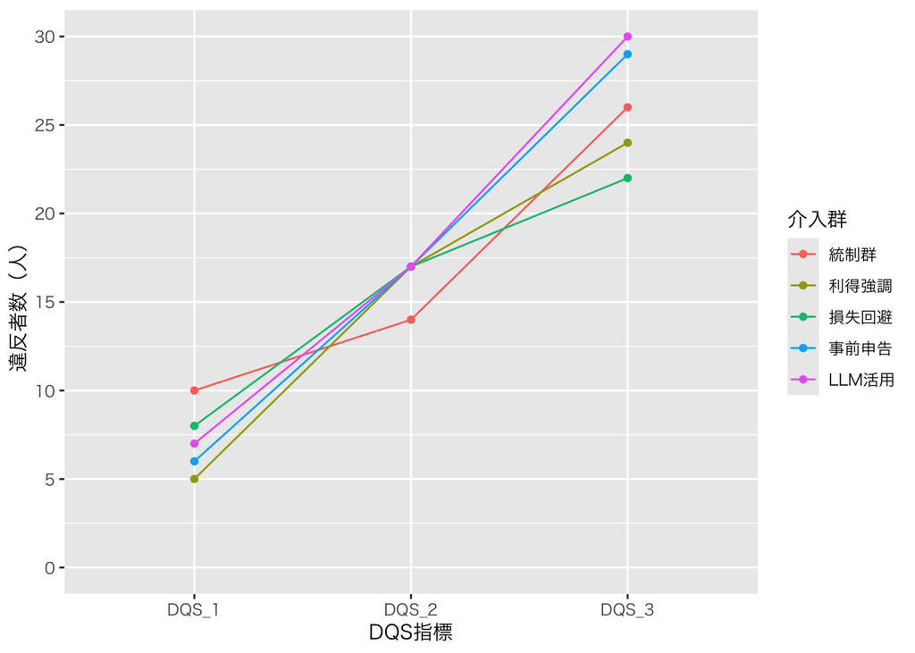

```r
# データ準備（違反者数をカウント）- ダミー回帰用データ
dummy_dqs_data <- dummy_all_data %>%
  group_by(category) %>%
  summarise(DQS_1 = sum(DQS_1 == 1, na.rm = TRUE),
            DQS_2 = sum(DQS_2 == 1, na.rm = TRUE),
            DQS_3 = sum(DQS_3 == 1, na.rm = TRUE)) %>%
  pivot_longer(cols = starts_with("DQS_"), names_to = "DQS", values_to = "count")

# 折れ線グラフ - ダミー回帰用データ
ggplot(dummy_dqs_data, aes(x = DQS, y = count, color = category, group = category)) +
  geom_line() + geom_point() +
  scale_y_continuous(limits = c(0, NA), breaks = seq(0, 200, 5)) +
  labs(x = "DQS指標", y = "違反者数（人）", color = "介入群") +
  theme(text = element_text(family = "HiraginoSans-W3"))
```

## ダミー回帰用データでのDQS1~3の違反者数推移グラフ

```r
# DQS1~3の違反者数推移（全体）- ダミー回帰用データ
dummy_dqs_trend_data <- dummy_all_data %>%
  summarise(DQS_1 = sum(DQS_1 == 1, na.rm = TRUE),
            DQS_2 = sum(DQS_2 == 1, na.rm = TRUE),
            DQS_3 = sum(DQS_3 == 1, na.rm = TRUE)) %>%
  pivot_longer(cols = starts_with("DQS_"), names_to = "DQS", values_to = "count") %>%
  mutate(DQS = factor(DQS, levels = c("DQS_1", "DQS_2", "DQS_3")))

# 違反者数を確認
cat("=== ダミー回帰用データでのDQS指標別違反者数 ===\n")
```

```
## === ダミー回帰用データでのDQS指標別違反者数 ===
```

```r
print(dummy_dqs_trend_data)
```

```
## # A tibble: 3 × 2
##   DQS   count
##   <fct> <int>
## 1 DQS_1    36
## 2 DQS_2    82
## 3 DQS_3   131
```

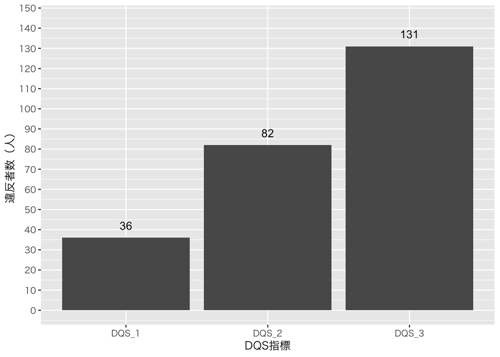

```r
# 棒グラフ（DQS1~3の推移）- ダミー回帰用データ
ggplot(dummy_dqs_trend_data, aes(x = DQS, y = count)) +
  geom_bar(stat = "identity") +
  geom_text(aes(label = count), vjust = -1, color = "black", size = 4) +
  scale_y_continuous(limits = c(0, max(dummy_dqs_trend_data$count) * 1.1), breaks = seq(0, 200, 10)) +
  labs(
       x = "DQS指標", y = "違反者数（人）") +
  theme(text = element_text(family = "HiraginoSans-W3"))
```

## ダミー回帰分析

### 共変量なしモデル

```r
# Or_DQSを従属変数としたダミー回帰分析（統制群を基準カテゴリとして使用）
model_or_dqs <- lm(Or_DQS ~ gain_emphasis + loss_aversion + pre_commitment + using_llm,
                   data = dummy_all_data)

# 回帰結果の表示
summary(model_or_dqs)
```

```
##
## Call:
## lm(formula = Or_DQS ~ gain_emphasis + loss_aversion + pre_commitment +
##     using_llm, data = dummy_all_data)
##
## Residuals:
##     Min      1Q  Median      3Q     Max
## -0.2500 -0.2416 -0.2260 -0.2023  0.7977
##
## Coefficients:
##                 Estimate Std. Error t value Pr(>|t|)
## (Intercept)     0.241573   0.031690   7.623 6.38e-14 ***
## gain_emphasis  -0.015584   0.044879  -0.347    0.728
## loss_aversion  -0.039326   0.044816  -0.877    0.380
## pre_commitment  0.008427   0.044943   0.188    0.851
## using_llm      -0.002684   0.044691  -0.060    0.952
## ---
## Signif. codes:  0 '***' 0.001 '**' 0.01 '*' 0.05 '.' 0.1 ' ' 1
##
## Residual standard error: 0.4228 on 884 degrees of freedom
## Multiple R-squared:  0.001553,   Adjusted R-squared:  -0.002965
## F-statistic: 0.3437 on 4 and 884 DF,  p-value: 0.8485
```

# 共変量ありモデル

```r
# Model 1: ベースライン（共変量なし）- 統制群を基準
model1 <- lm(Or_DQS ~ gain_emphasis + loss_aversion + pre_commitment + using_llm,
             data = dummy_all_data)

# Model 4: デバイス情報も追加（フルモデル）
model4 <- lm(Or_DQS ~ gain_emphasis + loss_aversion + pre_commitment + using_llm +
             player.q_gender + player.q_age + player.q_education + player.q_area + player.q_device,
             data = dummy_all_data)
```

```r
# 日本語ラベルを設定した回帰結果表
tab_model(model1, model4,
          show.aic = T,
          pred.labels = c(
            "(Intercept)" = "(Intercept)",
            "gain_emphasis" = "利得強調",
            "loss_aversion" = "損失回避",
            "pre_commitment" = "事前申告",
            "using_llm" = "LLM活用",
            "player.q_gender" = "性別",
            "player.q_age" = "年齢",
            "player.q_education" = "学歴",
            "player.q_area" = "居住地",
            "player.q_device" = "デバイス"
          ),
          dv.labels = c("共変量なしモデル", "共変量ありモデル"),
          string.pred = "変数")
```

|  | 共変量なしモデル |  |  | 共変量ありモデル |  |  |
| --- | --- | --- | --- | --- | --- | --- |
| 変数 | Estimates | CI | p | Estimates | CI | p |
| (Intercept) | 0.24 | 0.18 – 0.30 | **<0.001** | 0.43 | 0.28 – 0.57 | **<0.001** |
| 利得強調 | -0.02 | -0.10 – 0.07 | 0.728 | -0.01 | -0.10 – 0.07 | 0.747 |
| 損失回避 | -0.04 | -0.13 – 0.05 | 0.380 | -0.04 | -0.13 – 0.05 | 0.369 |
| 事前申告 | 0.01 | -0.08 – 0.10 | 0.851 | 0.01 | -0.08 – 0.10 | 0.807 |
| LLM活用 | -0.00 | -0.09 – 0.09 | 0.952 | -0.01 | -0.09 – 0.08 | 0.900 |
| 性別 |  |  |  | -0.01 | -0.07 – 0.05 | 0.755 |
| 年齢 |  |  |  | -0.04 | -0.06 – -0.01 | **0.003** |
| 学歴 |  |  |  | -0.02 | -0.04 – 0.00 | 0.050 |
| 居住地 |  |  |  | 0.00 | -0.01 – 0.02 | 0.779 |
| デバイス |  |  |  | 0.01 | -0.02 – 0.04 | 0.647 |
| Observations | 889 |  |  | 889 |  |  |
| R<sup>2</sup> / R<sup>2</sup> adjusted | 0.002 / -0.003 |  |  | 0.015 / 0.005 |  |  |
| AIC | 999.234 |  |  | 996.740 |  |  |

## Cohen’s d 効果量の計算

```r
# 統制群を基準としたCohen's dの計算
group_stats <- dummy_all_data %>%
  group_by(category) %>%
  summarise(
    mean_or_dqs = mean(Or_DQS, na.rm = TRUE),
    sd_or_dqs = sd(Or_DQS, na.rm = TRUE),
    n = n()
  )

# 統制群の値
control_mean <- group_stats$mean_or_dqs[group_stats$category == "統制群"]
control_sd <- group_stats$sd_or_dqs[group_stats$category == "統制群"]
control_n <- group_stats$n[group_stats$category == "統制群"]

# Cohen's d計算
cohens_d_results <- group_stats %>%
  filter(category != "統制群") %>%
  mutate(
    pooled_sd = sqrt(((control_n - 1) * control_sd^2 + (n - 1) * sd_or_dqs^2) / (control_n + n - 2)),
    cohens_d = (mean_or_dqs - control_mean) / pooled_sd
  ) %>%
  select(category, cohens_d) %>%
  mutate(cohens_d = round(cohens_d, 3))

kable(cohens_d_results,
      col.names = c("介入群", "Cohen's d"),
      caption = "統制群を基準としたCohen's d効果量")
```

統制群を基準としたCohen’s d効果量

| 介入群 | Cohen’s d |
| --- | --- |
| 利得強調 | -0.037 |
| 損失回避 | -0.094 |
| 事前申告 | 0.020 |
| LLM活用 | -0.006 |

## DQSごとの分析

### DQS1

```r
# DQS_1を従属変数としたダミー回帰分析（統制群を基準カテゴリとして使用）
model_dqs1 <- lm(DQS_1 ~ gain_emphasis + loss_aversion + pre_commitment + using_llm,
                   data = dummy_all_data)

# 回帰結果の表示
summary(model_dqs1)
```

```
##
## Call:
## lm(formula = DQS_1 ~ gain_emphasis + loss_aversion + pre_commitment +
##     using_llm, data = dummy_all_data)
##
## Residuals:
##      Min       1Q   Median       3Q      Max
## -0.05618 -0.04494 -0.03889 -0.03409  0.97175
##
## Coefficients:
##                Estimate Std. Error t value Pr(>|t|)
## (Intercept)     0.05618    0.01480   3.796 0.000157 ***
## gain_emphasis  -0.02793    0.02096  -1.333 0.182970
## loss_aversion  -0.01124    0.02093  -0.537 0.591492
## pre_commitment -0.02209    0.02099  -1.052 0.292879
## using_llm      -0.01729    0.02087  -0.828 0.407618
## ---
## Signif. codes:  0 '***' 0.001 '**' 0.01 '*' 0.05 '.' 0.1 ' ' 1
##
## Residual standard error: 0.1974 on 884 degrees of freedom
## Multiple R-squared:  0.002361,   Adjusted R-squared:  -0.002154
## F-statistic: 0.5229 on 4 and 884 DF,  p-value: 0.7189
```

```r
# Model 4: デバイス情報も追加（フルモデル）
model4_dqs1 <- lm(DQS_1 ~ gain_emphasis + loss_aversion + pre_commitment + using_llm +
             player.q_gender + player.q_age + player.q_education + player.q_area + player.q_device,
             data = dummy_all_data)

# 回帰結果の表示
summary(model4_dqs1)
```

```
##
## Call:
## lm(formula = DQS_1 ~ gain_emphasis + loss_aversion + pre_commitment +
##     using_llm + player.q_gender + player.q_age + player.q_education +
##     player.q_area + player.q_device, data = dummy_all_data)
##
## Residuals:
##      Min       1Q   Median       3Q      Max
## -0.10592 -0.05328 -0.03867 -0.02444  0.99975
##
## Coefficients:
##                     Estimate Std. Error t value Pr(>|t|)
## (Intercept)         0.085332   0.034822   2.451   0.0145 *
## gain_emphasis      -0.028188   0.020959  -1.345   0.1790
## loss_aversion      -0.010841   0.020932  -0.518   0.6046
## pre_commitment     -0.022178   0.020979  -1.057   0.2907
## using_llm          -0.021160   0.020907  -1.012   0.3118
## player.q_gender     0.022909   0.014393   1.592   0.1118
## player.q_age       -0.001990   0.005753  -0.346   0.7295
## player.q_education -0.003305   0.004786  -0.691   0.4900
## player.q_area      -0.007173   0.003717  -1.930   0.0540 .
## player.q_device     0.004473   0.006968   0.642   0.5211
## ---
## Signif. codes:  0 '***' 0.001 '**' 0.01 '*' 0.05 '.' 0.1 ' ' 1
##
## Residual standard error: 0.1971 on 879 degrees of freedom
## Multiple R-squared:  0.0115, Adjusted R-squared:  0.00138
## F-statistic: 1.136 on 9 and 879 DF,  p-value: 0.3338
```

```r
tab_model(model_dqs1, model4_dqs1,
          show.aic = T,
          pred.labels = c(
            "(Intercept)" = "(Intercept)",
            "gain_emphasis" = "利得強調",
            "loss_aversion" = "損失回避",
            "pre_commitment" = "事前申告",
            "using_llm" = "LLM活用",
            "player.q_gender" = "性別",
            "player.q_age" = "年齢",
            "player.q_education" = "学歴",
            "player.q_area" = "居住地",
            "player.q_device" = "デバイス"
          ),
          dv.labels = c("DQS1 共変量なしモデル", "DQS1 共変量ありモデル"),
          string.pred = "変数")
```

|  | DQS1 共変量なしモデル |  |  | DQS1 共変量ありモデル |  |  |
| --- | --- | --- | --- | --- | --- | --- |
| 変数 | Estimates | CI | p | Estimates | CI | p |
| (Intercept) | 0.06 | 0.03 – 0.09 | **<0.001** | 0.09 | 0.02 – 0.15 | **0.014** |
| 利得強調 | -0.03 | -0.07 – 0.01 | 0.183 | -0.03 | -0.07 – 0.01 | 0.179 |
| 損失回避 | -0.01 | -0.05 – 0.03 | 0.591 | -0.01 | -0.05 – 0.03 | 0.605 |
| 事前申告 | -0.02 | -0.06 – 0.02 | 0.293 | -0.02 | -0.06 – 0.02 | 0.291 |
| LLM活用 | -0.02 | -0.06 – 0.02 | 0.408 | -0.02 | -0.06 – 0.02 | 0.312 |
| 性別 |  |  |  | 0.02 | -0.01 – 0.05 | 0.112 |
| 年齢 |  |  |  | -0.00 | -0.01 – 0.01 | 0.730 |
| 学歴 |  |  |  | -0.00 | -0.01 – 0.01 | 0.490 |
| 居住地 |  |  |  | -0.01 | -0.01 – 0.00 | 0.054 |
| デバイス |  |  |  | 0.00 | -0.01 – 0.02 | 0.521 |
| Observations | 889 |  |  | 889 |  |  |
| R<sup>2</sup> / R<sup>2</sup> adjusted | 0.002 / -0.002 |  |  | 0.012 / 0.001 |  |  |
| AIC | -354.626 |  |  | -352.809 |  |  |

### DQS2

```r
# DQS_2を従属変数としたダミー回帰分析（統制群を基準カテゴリとして使用）
model_dqs2 <- lm(DQS_2 ~ gain_emphasis + loss_aversion + pre_commitment + using_llm,
                   data = dummy_all_data)

# 回帰結果の表示
summary(model_dqs2)
```

```
##
## Call:
## lm(formula = DQS_2 ~ gain_emphasis + loss_aversion + pre_commitment +
##     using_llm, data = dummy_all_data)
##
## Residuals:
##      Min       1Q   Median       3Q      Max
## -0.09659 -0.09605 -0.09551 -0.07865  0.92135
##
## Coefficients:
##                Estimate Std. Error t value Pr(>|t|)
## (Intercept)     0.07865    0.02174   3.617 0.000315 ***
## gain_emphasis   0.01739    0.03079   0.565 0.572327
## loss_aversion   0.01685    0.03075   0.548 0.583769
## pre_commitment  0.01794    0.03084   0.582 0.560896
## using_llm       0.01579    0.03066   0.515 0.606673
## ---
## Signif. codes:  0 '***' 0.001 '**' 0.01 '*' 0.05 '.' 0.1 ' ' 1
##
## Residual standard error: 0.2901 on 884 degrees of freedom
## Multiple R-squared:  0.000558,   Adjusted R-squared:  -0.003964
## F-statistic: 0.1234 on 4 and 884 DF,  p-value: 0.9741
```

```r
# Model 4: デバイス情報も追加（フルモデル）
model4_dqs2 <- lm(DQS_2 ~ gain_emphasis + loss_aversion + pre_commitment + using_llm +
             player.q_gender + player.q_age + player.q_education + player.q_area + player.q_device,
             data = dummy_all_data)

# 回帰結果の表示
summary(model4_dqs2)
```

```
##
## Call:
## lm(formula = DQS_2 ~ gain_emphasis + loss_aversion + pre_commitment +
##     using_llm + player.q_gender + player.q_age + player.q_education +
##     player.q_area + player.q_device, data = dummy_all_data)
##
## Residuals:
##      Min       1Q   Median       3Q      Max
## -0.14981 -0.10477 -0.08933 -0.07156  0.97247
##
## Coefficients:
##                     Estimate Std. Error t value Pr(>|t|)
## (Intercept)         0.125515   0.051275   2.448   0.0146 *
## gain_emphasis       0.018013   0.030861   0.584   0.5596
## loss_aversion       0.015608   0.030821   0.506   0.6127
## pre_commitment      0.019215   0.030892   0.622   0.5341
## using_llm           0.017800   0.030785   0.578   0.5633
## player.q_gender    -0.019053   0.021193  -0.899   0.3689
## player.q_age       -0.013964   0.008471  -1.648   0.0996 .
## player.q_education -0.001698   0.007047  -0.241   0.8096
## player.q_area       0.004974   0.005474   0.909   0.3637
## player.q_device    -0.001295   0.010260  -0.126   0.8996
## ---
## Signif. codes:  0 '***' 0.001 '**' 0.01 '*' 0.05 '.' 0.1 ' ' 1
##
## Residual standard error: 0.2902 on 879 degrees of freedom
## Multiple R-squared:  0.005435,   Adjusted R-squared:  -0.004749
## F-statistic: 0.5337 on 9 and 879 DF,  p-value: 0.8506
```

```r
tab_model(model_dqs2, model4_dqs2,
          show.aic = T,
          pred.labels = c(
            "(Intercept)" = "(Intercept)",
            "gain_emphasis" = "利得強調",
            "loss_aversion" = "損失回避",
            "pre_commitment" = "事前申告",
            "using_llm" = "LLM活用",
            "player.q_gender" = "性別",
            "player.q_age" = "年齢",
            "player.q_education" = "学歴",
            "player.q_area" = "居住地",
            "player.q_device" = "デバイス"
          ),
          dv.labels = c("DQS2 共変量なしモデル", "DQS2 共変量ありモデル"),
          string.pred = "変数")
```

|  | DQS2 共変量なしモデル |  |  | DQS2 共変量ありモデル |  |  |
| --- | --- | --- | --- | --- | --- | --- |
| 変数 | Estimates | CI | p | Estimates | CI | p |
| (Intercept) | 0.08 | 0.04 – 0.12 | **<0.001** | 0.13 | 0.02 – 0.23 | **0.015** |
| 利得強調 | 0.02 | -0.04 – 0.08 | 0.572 | 0.02 | -0.04 – 0.08 | 0.560 |
| 損失回避 | 0.02 | -0.04 – 0.08 | 0.584 | 0.02 | -0.04 – 0.08 | 0.613 |
| 事前申告 | 0.02 | -0.04 – 0.08 | 0.561 | 0.02 | -0.04 – 0.08 | 0.534 |
| LLM活用 | 0.02 | -0.04 – 0.08 | 0.607 | 0.02 | -0.04 – 0.08 | 0.563 |
| 性別 |  |  |  | -0.02 | -0.06 – 0.02 | 0.369 |
| 年齢 |  |  |  | -0.01 | -0.03 – 0.00 | 0.100 |
| 学歴 |  |  |  | -0.00 | -0.02 – 0.01 | 0.810 |
| 居住地 |  |  |  | 0.00 | -0.01 – 0.02 | 0.364 |
| デバイス |  |  |  | -0.00 | -0.02 – 0.02 | 0.900 |
| Observations | 889 |  |  | 889 |  |  |
| R<sup>2</sup> / R<sup>2</sup> adjusted | 0.001 / -0.004 |  |  | 0.005 / -0.005 |  |  |
| AIC | 329.522 |  |  | 335.173 |  |  |

### DQS3

```r
# DQS_3を従属変数としたダミー回帰分析（統制群を基準カテゴリとして使用）
model_dqs3 <- lm(DQS_3 ~ gain_emphasis + loss_aversion + pre_commitment + using_llm,
                   data = dummy_all_data)

# 回帰結果の表示
summary(model_dqs3)
```

```
##
## Call:
## lm(formula = DQS_3 ~ gain_emphasis + loss_aversion + pre_commitment +
##     using_llm, data = dummy_all_data)
##
## Residuals:
##     Min      1Q  Median      3Q     Max
## -0.1667 -0.1648 -0.1461 -0.1236  0.8764
##
## Coefficients:
##                Estimate Std. Error t value Pr(>|t|)
## (Intercept)     0.14607    0.02661   5.488  5.3e-08 ***
## gain_emphasis  -0.01047    0.03769  -0.278    0.781
## loss_aversion  -0.02247    0.03764  -0.597    0.551
## pre_commitment  0.01871    0.03774   0.496    0.620
## using_llm       0.02060    0.03753   0.549    0.583
## ---
## Signif. codes:  0 '***' 0.001 '**' 0.01 '*' 0.05 '.' 0.1 ' ' 1
##
## Residual standard error: 0.3551 on 884 degrees of freedom
## Multiple R-squared:  0.002201,   Adjusted R-squared:  -0.002314
## F-statistic: 0.4874 on 4 and 884 DF,  p-value: 0.745
```

```r
# Model 4: デバイス情報も追加（フルモデル）
model4_dqs3 <- lm(DQS_3 ~ gain_emphasis + loss_aversion + pre_commitment + using_llm +
             player.q_gender + player.q_age + player.q_education + player.q_area + player.q_device,
             data = dummy_all_data)

# 回帰結果の表示
summary(model4_dqs3)
```

```
##
## Call:
## lm(formula = DQS_3 ~ gain_emphasis + loss_aversion + pre_commitment +
##     using_llm + player.q_gender + player.q_age + player.q_education +
##     player.q_area + player.q_device, data = dummy_all_data)
##
## Residuals:
##      Min       1Q   Median       3Q      Max
## -0.32126 -0.17393 -0.12923 -0.07933  0.93863
##
## Coefficients:
##                     Estimate Std. Error t value Pr(>|t|)
## (Intercept)         0.311492   0.062254   5.004  6.8e-07 ***
## gain_emphasis      -0.008427   0.037470  -0.225   0.8221
## loss_aversion      -0.021818   0.037421  -0.583   0.5600
## pre_commitment      0.021557   0.037507   0.575   0.5656
## using_llm           0.019014   0.037377   0.509   0.6111
## player.q_gender    -0.019167   0.025732  -0.745   0.4565
## player.q_age       -0.033949   0.010285  -3.301   0.0010 **
## player.q_education -0.022598   0.008555  -2.641   0.0084 **
## player.q_area       0.006147   0.006646   0.925   0.3553
## player.q_device     0.011358   0.012457   0.912   0.3621
## ---
## Signif. codes:  0 '***' 0.001 '**' 0.01 '*' 0.05 '.' 0.1 ' ' 1
##
## Residual standard error: 0.3524 on 879 degrees of freedom
## Multiple R-squared:  0.02295,    Adjusted R-squared:  0.01295
## F-statistic: 2.295 on 9 and 879 DF,  p-value: 0.0151
```

```r
tab_model(model_dqs3, model4_dqs3,
          show.aic = T,
          pred.labels = c(
            "(Intercept)" = "(Intercept)",
            "gain_emphasis" = "利得強調",
            "loss_aversion" = "損失回避",
            "pre_commitment" = "事前申告",
            "using_llm" = "LLM活用",
            "player.q_gender" = "性別",
            "player.q_age" = "年齢",
            "player.q_education" = "学歴",
            "player.q_area" = "居住地",
            "player.q_device" = "デバイス"
          ),
          dv.labels = c("DQS3 共変量なしモデル", "DQS3 共変量ありモデル"),
          string.pred = "変数")
```

|  | DQS3 共変量なしモデル |  |  | DQS3 共変量ありモデル |  |  |
| --- | --- | --- | --- | --- | --- | --- |
| 変数 | Estimates | CI | p | Estimates | CI | p |
| (Intercept) | 0.15 | 0.09 – 0.20 | **<0.001** | 0.31 | 0.19 – 0.43 | **<0.001** |
| 利得強調 | -0.01 | -0.08 – 0.06 | 0.781 | -0.01 | -0.08 – 0.07 | 0.822 |
| 損失回避 | -0.02 | -0.10 – 0.05 | 0.551 | -0.02 | -0.10 – 0.05 | 0.560 |
| 事前申告 | 0.02 | -0.06 – 0.09 | 0.620 | 0.02 | -0.05 – 0.10 | 0.566 |
| LLM活用 | 0.02 | -0.05 – 0.09 | 0.583 | 0.02 | -0.05 – 0.09 | 0.611 |
| 性別 |  |  |  | -0.02 | -0.07 – 0.03 | 0.457 |
| 年齢 |  |  |  | -0.03 | -0.05 – -0.01 | **0.001** |
| 学歴 |  |  |  | -0.02 | -0.04 – -0.01 | **0.008** |
| 居住地 |  |  |  | 0.01 | -0.01 – 0.02 | 0.355 |
| デバイス |  |  |  | 0.01 | -0.01 – 0.04 | 0.362 |
| Observations | 889 |  |  | 889 |  |  |
| R<sup>2</sup> / R<sup>2</sup> adjusted | 0.002 / -0.002 |  |  | 0.023 / 0.013 |  |  |
| AIC | 688.849 |  |  | 680.163 |  |  |

## ANOVA分析

### 実験条件間の群間比較

```r
# 一元配置分散分析（ANOVA）
# H0: すべての実験条件で不真面目回答率に差がない
# H1: 少なくとも一つの実験条件で不真面目回答率に差がある

model1 <- lm(Or_DQS ~ category,
             data = dummy_all_data)

anova_result_model1 <- anova(model1) %>%
  tidy()

#出力結果
anova_result_model1
```

```
## # A tibble: 2 × 6
##   term         df   sumsq meansq statistic p.value
##   <chr>     <int>   <dbl>  <dbl>     <dbl>   <dbl>
## 1 category      4   0.246 0.0614     0.344   0.848
## 2 Residuals   884 158.    0.179     NA      NA
```

```r
# ANOVA結果をHTMLテーブルで出力（日本語版）
anova_result_model1 %>%
  mutate(term = case_when(
    term == "category" ~ "実験条件",
    term == "Residuals" ~ "残差",
    TRUE ~ term
  )) %>%
  kable(format = "html",
        caption = "一元配置分散分析結果（実験条件間の比較）",
        col.names = c("要因", "自由度", "平方和", "平均平方", "F値", "p値")) %>%
  kable_styling(bootstrap_options = c("striped", "hover", "condensed", "responsive"))
```

一元配置分散分析結果（実験条件間の比較）

| 要因 | 自由度 | 平方和 | 平均平方 | F値 | p値 |
| --- | --- | --- | --- | --- | --- |
| 実験条件 | 4 | 0.2457764 | 0.0614441 | 0.343733 | 0.8484562 |
| 残差 | 884 | 158.0196904 | 0.1787553 | NA | NA |

```r
# 共変量を考慮したANOVA分析（model4と同じモデル式）
# フルモデル（すべての共変量を含む）でのANOVA

model4 <- lm(Or_DQS ~ category +
                   player.q_gender + player.q_age + player.q_education + player.q_area + player.q_device,
                   data = dummy_all_data)

anova_result_model4 <- anova(model4) %>%
  tidy()
```

```r
# ANOVA結果をHTMLテーブルで出力（日本語版・共変量あり）
anova_result_model4 %>%
  mutate(term = case_when(
    term == "category" ~ "実験条件",
    term == "player.q_gender" ~ "性別",
    term == "player.q_age" ~ "年齢",
    term == "player.q_education" ~ "学歴",
    term == "player.q_area" ~ "居住地",
    term == "player.q_device" ~ "デバイス",
    term == "Residuals" ~ "残差",
    TRUE ~ term
  )) %>%
  kable(format = "html",
        caption = "共変量を考慮した分散分析結果",
        col.names = c("要因", "自由度", "平方和", "平均平方", "F値", "p値")) %>%
  kable_styling(bootstrap_options = c("striped", "hover", "condensed", "responsive"))
```

共変量を考慮した分散分析結果

| 要因 | 自由度 | 平方和 | 平均平方 | F値 | p値 |
| --- | --- | --- | --- | --- | --- |
| 実験条件 | 4 | 0.2457764 | 0.0614441 | 0.3466262 | 0.8464535 |
| 性別 | 1 | 0.0115900 | 0.0115900 | 0.0653828 | 0.7982418 |
| 年齢 | 1 | 1.4301578 | 1.4301578 | 8.0679861 | 0.0046095 |
| 学歴 | 1 | 0.7130396 | 0.7130396 | 4.0224886 | 0.0452035 |
| 居住地 | 1 | 0.0131911 | 0.0131911 | 0.0744152 | 0.7850776 |
| デバイス | 1 | 0.0372797 | 0.0372797 | 0.2103070 | 0.6466403 |
| 残差 | 879 | 155.8144323 | 0.1772633 | NA | NA |

## DQS指標間同質性検定（カイ二乗検定）

**帰無仮説（H₀）**: DQS1、DQS2、DQS3の違反パターンは同質である（真面目・不真面目の分布に差がない）  
**対立仮説（H₁）**: DQS1、DQS2、DQS3の違反パターンは同質でない（真面目・不真面目の分布に差がある）

```r
# ダミー回帰用データを使用（既にNAが除外されている）
clean_data <- dummy_all_data

# DQS指標別の違反者数を集計
dqs_counts <- clean_data %>%
  summarise(
    DQS_1_honest = sum(DQS_1 == 0, na.rm = TRUE),
    DQS_1_dishonest = sum(DQS_1 == 1, na.rm = TRUE),
    DQS_2_honest = sum(DQS_2 == 0, na.rm = TRUE),
    DQS_2_dishonest = sum(DQS_2 == 1, na.rm = TRUE),
    DQS_3_honest = sum(DQS_3 == 0, na.rm = TRUE),
    DQS_3_dishonest = sum(DQS_3 == 1, na.rm = TRUE)
  )

# クロス集計表の作成（行：真面目/不真面目、列：DQS1/DQS2/DQS3）
crosstab_matrix <- matrix(c(
  dqs_counts$DQS_1_honest, dqs_counts$DQS_2_honest, dqs_counts$DQS_3_honest,
  dqs_counts$DQS_1_dishonest, dqs_counts$DQS_2_dishonest, dqs_counts$DQS_3_dishonest
), nrow = 2, byrow = TRUE)

rownames(crosstab_matrix) <- c("真面目回答", "不真面目回答")
colnames(crosstab_matrix) <- c("DQS_1", "DQS_2", "DQS_3")

cat("=== DQS指標間同質性検定のクロス集計表 ===\n")
```

```
## === DQS指標間同質性検定のクロス集計表 ===
```

```r
cat("行：回答態度、列：DQS指標\n\n")
```

```
## 行：回答態度、列：DQS指標
```

```r
print(crosstab_matrix)
```

```
##              DQS_1 DQS_2 DQS_3
## 真面目回答     853   807   758
## 不真面目回答    36    82   131
```

```r
# カイ二乗検定の実行
chi_test_homogeneity <- chisq.test(crosstab_matrix)

cat("\n=== 検定結果 ===\n")
```

```
##
## === 検定結果 ===
```

```r
cat("カイ二乗統計量:", round(chi_test_homogeneity$statistic, 4), "\n")
```

```
## カイ二乗統計量: 59.986
```

```r
cat("p値:", round(chi_test_homogeneity$p.value, 4), "\n")
```

```
## p値: 0
```

```r
cat("自由度:", chi_test_homogeneity$parameter, "\n")
```

```
## 自由度: 2
```

```r
# 期待度数の表示
cat("\n=== 期待度数 ===\n")
```

```
##
## === 期待度数 ===
```

```r
print(round(chi_test_homogeneity$expected, 2))
```

```
##              DQS_1 DQS_2 DQS_3
## 真面目回答     806   806   806
## 不真面目回答    83    83    83
```

```r
# 残差の表示
cat("\n=== 標準化残差 ===\n")
```

```
##
## === 標準化残差 ===
```

```r
print(round(chi_test_homogeneity$residuals, 3))
```

```
##               DQS_1  DQS_2  DQS_3
## 真面目回答    1.656  0.035 -1.691
## 不真面目回答 -5.159 -0.110  5.269
```

## 不真面目回答者のみでの同質性検定

**帰無仮説（H₀）**: 不真面目回答者において、DQS1、DQS2、DQS3の違反数は同質である  
**対立仮説（H₁）**: 不真面目回答者において、DQS1、DQS2、DQS3の違反数は同質でない

```r
# 不真面目回答者のみの違反数を集計
dishonest_counts <- clean_data %>%
  summarise(
    DQS_1_dishonest = sum(DQS_1 == 1, na.rm = TRUE),
    DQS_2_dishonest = sum(DQS_2 == 1, na.rm = TRUE),
    DQS_3_dishonest = sum(DQS_3 == 1, na.rm = TRUE)
  )

# 不真面目回答者数のベクトル作成
dishonest_vector <- c(
  dishonest_counts$DQS_1_dishonest,
  dishonest_counts$DQS_2_dishonest,
  dishonest_counts$DQS_3_dishonest
)
names(dishonest_vector) <- c("DQS_1", "DQS_2", "DQS_3")

cat("=== 不真面目回答者数（DQS指標別） ===\n")
```

```
## === 不真面目回答者数（DQS指標別） ===
```

```r
print(dishonest_vector)
```

```
## DQS_1 DQS_2 DQS_3
##    36    82   131
```

```r
# 適合度検定（各DQS指標で同じ違反数が期待される）
chi_test_dishonest_only <- chisq.test(dishonest_vector)

cat("\n=== 不真面目回答者のみでの同質性検定結果 ===\n")
```

```
##
## === 不真面目回答者のみでの同質性検定結果 ===
```

```r
cat("カイ二乗統計量:", round(chi_test_dishonest_only$statistic, 4), "\n")
```

```
## カイ二乗統計量: 54.3855
```

```r
cat("p値:", round(chi_test_dishonest_only$p.value, 4), "\n")
```

```
## p値: 0
```

```r
cat("自由度:", chi_test_dishonest_only$parameter, "\n")
```

```
## 自由度: 2
```

```r
# 期待度数の表示
cat("\n=== 期待度数（各DQS指標で同数の違反を仮定） ===\n")
```

```
##
## === 期待度数（各DQS指標で同数の違反を仮定） ===
```

```r
print(round(chi_test_dishonest_only$expected, 2))
```

```
## DQS_1 DQS_2 DQS_3
##    83    83    83
```

```r
# 残差の表示
cat("\n=== 残差（観測値 - 期待値） ===\n")
```

```
##
## === 残差（観測値 - 期待値） ===
```

```r
residuals_dishonest <- dishonest_vector - chi_test_dishonest_only$expected
print(round(residuals_dishonest, 2))
```

```
## DQS_1 DQS_2 DQS_3
##   -47    -1    48
```

```r
# 各DQS指標の違反率
total_n <- nrow(clean_data)
violation_rates <- round(dishonest_vector / total_n * 100, 2)
cat("\n=== DQS指標別違反率 ===\n")
```

```
##
## === DQS指標別違反率 ===
```

```r
for(i in 1:3) {
  cat(names(violation_rates)[i], ":", violation_rates[i], "%\n")
}
```

```
## DQS_1 : 4.05 %
## DQS_2 : 9.22 %
## DQS_3 : 14.74 %
```

## DQS指標間同質性検定結果のまとめ

```r
# 違反者数の表（真面目回答・不真面目回答の数）
violation_count_homogeneity <- data.frame(
  項目 = c("DQS_1 真面目回答", "DQS_1 不真面目回答",
           "DQS_2 真面目回答", "DQS_2 不真面目回答",
           "DQS_3 真面目回答", "DQS_3 不真面目回答"),
  値 = c(dqs_counts$DQS_1_honest, dqs_counts$DQS_1_dishonest,
         dqs_counts$DQS_2_honest, dqs_counts$DQS_2_dishonest,
         dqs_counts$DQS_3_honest, dqs_counts$DQS_3_dishonest)
)

kable(violation_count_homogeneity, caption = "DQS指標別回答者数")
```

DQS指標別回答者数

| 項目 | 値 |
| --- | --- |
| DQS_1 真面目回答 | 853 |
| DQS_1 不真面目回答 | 36 |
| DQS_2 真面目回答 | 807 |
| DQS_2 不真面目回答 | 82 |
| DQS_3 真面目回答 | 758 |
| DQS_3 不真面目回答 | 131 |

```r
# 検定結果の表
homogeneity_test_results <- data.frame(
  項目 = c("カイ二乗統計量", "自由度", "p値", "判定"),
  値 = c(round(chi_test_homogeneity$statistic, 3),
         chi_test_homogeneity$parameter,
         format(chi_test_homogeneity$p.value, scientific = TRUE, digits = 3),
         ifelse(chi_test_homogeneity$p.value < 0.05, "有意", "非有意"))
)

kable(homogeneity_test_results, caption = "DQS指標間同質性検定結果")
```

DQS指標間同質性検定結果

| 項目 | 値 |
| --- | --- |
| カイ二乗統計量 | 59.986 |
| 自由度 | 2 |
| p値 | 9.42e-14 |
| 判定 | 有意 |

## 不真面目回答者のみでの同質性検定結果まとめ

```r
# 違反者数の表
violation_count_data <- data.frame(
  値 = c(dishonest_vector[1], dishonest_vector[2], dishonest_vector[3])
)

kable(violation_count_data, caption = "DQS指標別違反者数")
```

DQS指標別違反者数

|  | 値 |
| --- | --- |
| DQS_1 | 36 |
| DQS_2 | 82 |
| DQS_3 | 131 |

```r
# 検定結果の表
test_result_data <- data.frame(
  項目 = c("カイ二乗統計量", "自由度", "p値"),
  値 = c(round(chi_test_dishonest_only$statistic, 3),
         chi_test_dishonest_only$parameter,
         format(chi_test_dishonest_only$p.value, scientific = TRUE, digits = 3))
)

kable(test_result_data, caption = "DQSごとの不真面目回答者数に関するχ自乗検定")
```

DQSごとの不真面目回答者数に関するχ自乗検定

|  | 項目 | 値 |
| --- | --- | --- |
| X-squared | カイ二乗統計量 | 54.386 |
| df | 自由度 | 2 |
|  | p値 | 1.55e-12 |

## 介入群×DQS指標のクロス集計における検定

**帰無仮説（H₀）**: 介入群とDQS指標の違反パターンは独立である  
**対立仮説（H₁）**: 介入群とDQS指標の違反パターンは独立でない

```r
# 介入群×DQS指標の不真面目回答者数のクロス集計表を作成
intervention_dqs_crosstab <- clean_data %>%
  select(category, DQS_1, DQS_2, DQS_3) %>%
  pivot_longer(cols = starts_with("DQS_"), names_to = "DQS_indicator", values_to = "violation") %>%
  filter(violation == 1) %>%  # 不真面目回答者のみ
  count(category, DQS_indicator) %>%
  pivot_wider(names_from = DQS_indicator, values_from = n, values_fill = 0)

# クロス集計表をマトリックス形式に変換
crosstab_matrix_intervention <- as.matrix(intervention_dqs_crosstab[,-1])
rownames(crosstab_matrix_intervention) <- intervention_dqs_crosstab$category


print(crosstab_matrix_intervention)
```

```
##          DQS_1 DQS_2 DQS_3
## 統制群      10    14    26
## 利得強調     5    17    24
## 損失回避     8    17    22
## 事前申告     6    17    29
## LLM活用      7    17    30
```

```r
# カイ二乗検定の実行
chi_test_intervention_dqs <- chisq.test(crosstab_matrix_intervention)


cat("カイ二乗統計量:", round(chi_test_intervention_dqs$statistic, 4), "\n")
```

```
## カイ二乗統計量: 3.3497
```

```r
cat("p値:", round(chi_test_intervention_dqs$p.value, 4), "\n")
```

```
## p値: 0.9105
```

```r
cat("自由度:", chi_test_intervention_dqs$parameter, "\n")
```

```
## 自由度: 8
```

```r
# 期待度数の表示
cat("\n=== 期待度数 ===\n")
```

```
##
## === 期待度数 ===
```

```r
print(round(chi_test_intervention_dqs$expected, 2))
```

```
##          DQS_1 DQS_2 DQS_3
## 統制群    7.23 16.47 26.31
## 利得強調  6.65 15.15 24.20
## 損失回避  6.80 15.48 24.73
## 事前申告  7.52 17.12 27.36
## LLM活用   7.81 17.78 28.41
```

```r
# 標準化残差の表示
cat("\n=== 標準化残差 ===\n")
```

```
##
## === 標準化残差 ===
```

```r
print(round(chi_test_intervention_dqs$residuals, 3))
```

```
##           DQS_1  DQS_2  DQS_3
## 統制群    1.031 -0.608 -0.060
## 利得強調 -0.640  0.476 -0.041
## 損失回避  0.462  0.387 -0.548
## 事前申告 -0.554 -0.030  0.314
## LLM活用  -0.289 -0.186  0.298
```

```r
# 検定結果の表
intervention_dqs_test_results <- data.frame(
  項目 = c("カイ二乗統計量", "自由度", "p値", "判定"),
  値 = c(round(chi_test_intervention_dqs$statistic, 3),
         chi_test_intervention_dqs$parameter,
         format(chi_test_intervention_dqs$p.value, scientific = TRUE, digits = 3),
         ifelse(chi_test_intervention_dqs$p.value < 0.05, "有意", "非有意"))
)

kable(intervention_dqs_test_results, caption = "介入群×DQS指標の独立性検定結果")
```

介入群×DQS指標の独立性検定結果

| 項目 | 値 |
| --- | --- |
| カイ二乗統計量 | 3.35 |
| 自由度 | 8 |
| p値 | 9.11e-01 |
| 判定 | 非有意 |

## GLMM（ロジスティック混合モデル）を用いたlong-format解析

```r
# 追加パッケージ（インストールされていない場合は事前にインストールしてください）
pacman::p_load(lme4, lmerTest, broom.mixed, sjPlot, glmmTMB)
# データの整形（long format）
glmm_data <- dummy_all_data %>%
  select(participant.id_in_session, category, DQS_1, DQS_2, DQS_3) %>%
  pivot_longer(cols = starts_with("DQS_"), names_to = "DQS", values_to = "violation") %>%
  mutate(
    DQS = factor(DQS, levels = c("DQS_1", "DQS_2", "DQS_3")),
    category = factor(category, levels = c("統制群", "利得強調", "損失回避", "事前申告", "LLM活用")),
    violation = as.integer(violation)
  )

# 確認（簡単なクロス集計）
print(table(glmm_data$category, glmm_data$DQS))
```

```
##
##            DQS_1 DQS_2 DQS_3
##   統制群     178   178   178
##   利得強調   177   177   177
##   損失回避   178   178   178
##   事前申告   176   176   176
##   LLM活用    180   180   180
```

```r
print(table(glmm_data$DQS, glmm_data$violation))
```

```
##
##           0   1
##   DQS_1 853  36
##   DQS_2 807  82
##   DQS_3 758 131
```

```r
## モデル適合上の確認: データに極端な偏り（完全分離やカテゴリ内ゼロ）がないか確認します
cat("\n=== 被験者ごとの違反数サマリ（最小・最大・中央値等） ===\n")
```

```
##
## === 被験者ごとの違反数サマリ（最小・最大・中央値等） ===
```

```r
print(summary(as.integer(table(glmm_data$participant.id_in_session))))
```

```
##    Min. 1st Qu.  Median    Mean 3rd Qu.    Max.
##    3.00   12.00   15.00   13.68   15.00   15.00
```

```r
cat("\n=== 介入群×違反の頻度 ===\n")
```

```
##
## === 介入群×違反の頻度 ===
```

```r
print(table(glmm_data$category, glmm_data$violation))
```

```
##
##              0   1
##   統制群   484  50
##   利得強調 485  46
##   損失回避 487  47
##   事前申告 476  52
##   LLM活用  486  54
```

```r
# モデル1: まずは glmer を最適化オプションを変更して試行
glmm1 <- tryCatch(
  glmer(violation ~ category + (1 | participant.id_in_session),
        data = glmm_data,
        family = binomial(link = "logit"),
        control = glmerControl(optimizer = "nloptwrap", calc.derivs = FALSE, optCtrl = list(maxfun = 2e5))),
  warning = function(w) { w; invokeRestart("muffleWarning") },
  error = function(e) e
)

if(inherits(glmm1, "error")){
  cat("glmer failed: switching to glmmTMB for more robust fitting.\n")
  glmm1_tmb <- glmmTMB(violation ~ category + (1 | participant.id_in_session),
                       data = glmm_data,
                       family = binomial())
  print(summary(glmm1_tmb))
  tidy_glmm1 <- broom.mixed::tidy(glmm1_tmb, effects = "fixed", conf.int = TRUE, exponentiate = TRUE)
} else {
  # glmer 成功（又は警告を抑えた）場合は結果を表示
  print(summary(glmm1))
  tidy_glmm1 <- broom.mixed::tidy(glmm1, effects = "fixed", conf.int = TRUE, conf.level = 0.95, exponentiate = TRUE)
}
```

```
## Generalized linear mixed model fit by maximum likelihood (Laplace
##   Approximation) [glmerMod]
##  Family: binomial  ( logit )
## Formula: violation ~ category + (1 | participant.id_in_session)
##    Data: glmm_data
## Control:
## glmerControl(optimizer = "nloptwrap", calc.derivs = FALSE, optCtrl = list(maxfun = 2e+05))
##
##       AIC       BIC    logLik -2*log(L)  df.resid
##    1661.0    1696.3    -824.5    1649.0      2661
##
## Scaled residuals:
##     Min      1Q  Median      3Q     Max
## -0.4911 -0.3222 -0.2973 -0.2771  3.4710
##
## Random effects:
##  Groups                    Name        Variance Std.Dev.
##  participant.id_in_session (Intercept) 0.2176   0.4665
## Number of obs: 2667, groups:  participant.id_in_session, 195
##
## Fixed effects:
##                  Estimate Std. Error z value Pr(>|z|)
## (Intercept)      -2.34270    0.15553 -15.062   <2e-16 ***
## category利得強調 -0.09516    0.21950  -0.434    0.665
## category損失回避 -0.08087    0.21804  -0.371    0.711
## category事前申告  0.01502    0.21446   0.070    0.944
## categoryLLM活用   0.06473    0.21128   0.306    0.759
## ---
## Signif. codes:  0 '***' 0.001 '**' 0.01 '*' 0.05 '.' 0.1 ' ' 1
```

```
##
## Correlation of Fixed Effects:
```

```
##                 (Intr) ct利得強調 ct損失回避 ct事前申告
## categry利得強調 -0.675
## categry損失回避 -0.680  0.482
## categry事前申告 -0.691  0.490      0.494
## catgryLLM活用   -0.701  0.497      0.501      0.509
```

```r
# 表示: tidy のデフォルト出力をそのまま表示
tidy_glmm1 %>%
  select(term, estimate, conf.low, conf.high, p.value) %>%
  kable(col.names = c("項目", "オッズ比", "95%下限", "95%上限", "p値"), caption = "GLMM: 介入群のオッズ比 (参照: 統制群)")
```

GLMM: 介入群のオッズ比 (参照: 統制群)

| 項目 | オッズ比 | 95%下限 | 95%上限 | p値 |
| --- | --- | --- | --- | --- |
| (Intercept) | 0.0960680 | 0.0708255 | 0.130307 | 0.0000000 |
| category利得強調 | 0.9092247 | 0.5913347 | 1.398006 | 0.6646180 |
| category損失回避 | 0.9223141 | 0.6015697 | 1.414073 | 0.7107130 |
| category事前申告 | 1.0151341 | 0.6667681 | 1.545511 | 0.9441619 |
| categoryLLM活用 | 1.0668685 | 0.7051249 | 1.614194 | 0.7593344 |

```r
# モデル2: DQS指標との交互作用を含めたモデル（介入群ごとにDQSで効果が異なるか）
# モデル2: 交互作用モデル。glmer を試し、失敗したら glmmTMB にフォールバック
glmm2 <- tryCatch(
  glmer(violation ~ category * DQS + (1 | participant.id_in_session),
        data = glmm_data,
        family = binomial(link = "logit"),
        control = glmerControl(optimizer = "nloptwrap", calc.derivs = FALSE, optCtrl = list(maxfun = 2e5))),
  warning = function(w) { w; invokeRestart("muffleWarning") },
  error = function(e) e
)

if(inherits(glmm2, "error")){
  cat("glmer (interaction) failed: switching to glmmTMB.\n")
  glmm2_tmb <- glmmTMB(violation ~ category * DQS + (1 | participant.id_in_session),
                       data = glmm_data,
                       family = binomial())
  print(summary(glmm2_tmb))
  tidy_glmm2 <- broom.mixed::tidy(glmm2_tmb, effects = "fixed", conf.int = TRUE, exponentiate = TRUE)
} else {
  print(summary(glmm2))
  tidy_glmm2 <- broom.mixed::tidy(glmm2, effects = "fixed", conf.int = TRUE, exponentiate = TRUE)
}
```

```
## Generalized linear mixed model fit by maximum likelihood (Laplace
##   Approximation) [glmerMod]
##  Family: binomial  ( logit )
## Formula: violation ~ category * DQS + (1 | participant.id_in_session)
##    Data: glmm_data
## Control:
## glmerControl(optimizer = "nloptwrap", calc.derivs = FALSE, optCtrl = list(maxfun = 2e+05))
##
##       AIC       BIC    logLik -2*log(L)  df.resid
##    1613.0    1707.3    -790.5    1581.0      2651
##
## Scaled residuals:
##     Min      1Q  Median      3Q     Max
## -0.7048 -0.3550 -0.2762 -0.1897  6.3733
##
## Random effects:
##  Groups                    Name        Variance Std.Dev.
##  participant.id_in_session (Intercept) 0.252    0.502
## Number of obs: 2667, groups:  participant.id_in_session, 195
##
## Fixed effects:
##                            Estimate Std. Error z value Pr(>|z|)
## (Intercept)               -2.940154   0.340009  -8.647  < 2e-16 ***
## category利得強調          -0.707907   0.579030  -1.223  0.22149
## category損失回避          -0.221114   0.502729  -0.440  0.66006
## category事前申告          -0.522368   0.546965  -0.955  0.33956
## categoryLLM活用           -0.379562   0.522909  -0.726  0.46792
## DQSDQS_2                   0.377202   0.443208   0.851  0.39473
## DQSDQS_3                   1.093605   0.401394   2.725  0.00644 **
## category利得強調:DQSDQS_2  0.934632   0.697193   1.341  0.18006
## category損失回避:DQSDQS_2  0.431436   0.635232   0.679  0.49703
## category事前申告:DQSDQS_2  0.745175   0.670827   1.111  0.26664
## categoryLLM活用:DQSDQS_2   0.582604   0.651286   0.895  0.37103
## category利得強調:DQSDQS_3  0.617631   0.657646   0.939  0.34765
## category損失回避:DQSDQS_3  0.005791   0.595141   0.010  0.99224
## category事前申告:DQSDQS_3  0.658129   0.623636   1.055  0.29128
## categoryLLM活用:DQSDQS_3   0.534673   0.601554   0.889  0.37410
## ---
## Signif. codes:  0 '***' 0.001 '**' 0.01 '*' 0.05 '.' 0.1 ' ' 1
```

```r
tidy_glmm2 %>%
  filter(str_detect(term, "category")) %>%
  select(term, estimate, conf.low, conf.high, p.value) %>%
  kable(col.names = c("項目", "オッズ比", "95%下限", "95%上限", "p値"), caption = "GLMM（交互作用あり）：介入群×DQS のオッズ比")
```

GLMM（交互作用あり）：介入群×DQS のオッズ比

| 項目 | オッズ比 | 95%下限 | 95%上限 | p値 |
| --- | --- | --- | --- | --- |
| category利得強調 | 0.4926741 | 0.1583757 | 1.532607 | 0.2214903 |
| category損失回避 | 0.8016253 | 0.2992596 | 2.147310 | 0.6600619 |
| category事前申告 | 0.5931146 | 0.2030303 | 1.732672 | 0.3395632 |
| categoryLLM活用 | 0.6841613 | 0.2455035 | 1.906599 | 0.4679213 |
| category利得強調:DQSDQS_2 | 2.5462751 | 0.6493125 | 9.985203 | 0.1800620 |
| category損失回避:DQSDQS_2 | 1.5394661 | 0.4432610 | 5.346637 | 0.4970251 |
| category事前申告:DQSDQS_2 | 2.1068103 | 0.5657390 | 7.845755 | 0.2666416 |
| categoryLLM活用:DQSDQS_2 | 1.7906960 | 0.4996270 | 6.417972 | 0.3710309 |
| category利得強調:DQSDQS_3 | 1.8545294 | 0.5110273 | 6.730128 | 0.3476519 |
| category損失回避:DQSDQS_3 | 1.0058079 | 0.3132779 | 3.229240 | 0.9922362 |
| category事前申告:DQSDQS_3 | 1.9311758 | 0.5688289 | 6.556347 | 0.2912840 |
| categoryLLM活用:DQSDQS_3 | 1.7068907 | 0.5250029 | 5.549447 | 0.3740999 |

```r
# モデル比較（簡易）
data.frame(model = c("glmm1", "glmm2"), AIC = c(AIC(glmm1), AIC(glmm2)), BIC = c(BIC(glmm1), BIC(glmm2))) %>%
  kable(col.names = c("モデル", "AIC", "BIC"))
```

| モデル | AIC | BIC |
| --- | --- | --- |
| glmm1 | 1660.963 | 1696.295 |
| glmm2 | 1613.035 | 1707.254 |